# Exploring models for PLS density

Kelly Heilman

January 25, 2017

## Thinking about model design:

Ideally, we want to model denisty or savanna/forest

model density ~ f(environmental variables) density ~ smooth(MAP) (in previous versions, climate was negative correlated with density??) density ~ smooth(temp) density ~ smooth(soil/sand) density ~ smooth(precip. seasonality) density ~ smooth(temp. seasonality) density ~ smooth(MAP + temp) density ~ smooth(MAP) + smooth(temp) + smooth(soil)

Generalized additive model: allows for non-linearities…

Alternatively, we could us the classification scheme of savanna and forest; this isn’t as great, but it would allow us to use a logistic model, and to model the probability of forest, rather than tree density.

Model Selection/Cross Validation Options:

- leave one out CV (for gam’s, the GCV value is similar), it may not be feasible to do this for our # of data points
- for now, we split into test and training 50/50
- Use information criterion AIC (min)
- Need to decide whether Model prediction should be on PLS density or on PLS classification (savanna vs. forest)?

[output not shown]

[output not shown]

|  | model | modeltype | formula | df | AIC |
| --- | --- | --- | --- | --- | --- |
| **PLS.gam1** | PLS.gam1 | smooth | PLSdensity ~ s(MAP1910) | 10.34 | 54348 |
| **PLS.gam2** | PLS.gam2 | smooth | PLSdensity ~ s(pasttmean) | 10.65 | 54404 |
| **PLS.gam3** | PLS.gam3 | smooth | PLSdensity ~ s(pastdeltaP) | 10.55 | 54961 |
| **PLS.gam4** | PLS.gam4 | smooth | PLSdensity ~ s(pastdeltaT) | 10.75 | 54957 |
| **PLS.gam5** | PLS.gam5 | smooth | PLSdensity ~ s(awc) | 7.734 | 53068 |
| **PLS.gam6** | PLS.gam6 | smooth | PLSdensity ~ s(sandpct) | 10.76 | 55160 |
| **PLS.gam7** | PLS.gam7 | smooth | PLSdensity ~ s(pasttmean) + s(MAP1910) | 19.17 | 53032 |
| **PLS.gam8** | PLS.gam8 | smooth | PLSdensity ~ s(awc) + s(sandpct) | 16.54 | 52721 |
| **PLS.gam9** | PLS.gam9 | smooth | PLSdensity ~ s(MAP1910) + s(pasttmean) + s(sandpct) | 27.14 | 52851 |
| **PLS.gam10** | PLS.gam10 | smooth | PLSdensity ~ s(MAP1910) + s(pasttmean) + s(awc) | 26.14 | 51360 |
| **PLS.gam11** | PLS.gam11 | smooth | PLSdensity ~ s(MAP1910) + s(pasttmean) + s(sandpct) + s(awc) | 33.84 | 51264 |
| **PLS.gam12** | PLS.gam12 | smooth | PLSdensity ~ s(MAP1910) + s(pasttmean) + s(pastdeltaP) | 28.23 | 51334 |
| **PLS.gam13** | PLS.gam13 | smooth | PLSdensity ~ s(MAP1910) + s(pasttmean) + s(pastdeltaT) | 27.59 | 51435 |
| **PLS.gam14** | PLS.gam14 | smooth | PLSdensity ~ s(MAP1910) + s(pasttmean) + s(pastdeltaT) + s(pastdeltaP) | 36.39 | 51142 |
| **PLS.gam1L** | PLS.gam1L | linear | PLSdensity ~ MAP1910 | 3 | 55428 |
| **PLS.gam2L** | PLS.gam2L | linear | PLSdensity ~ pasttmean | 3 | 54921 |
| **PLS.gam3L** | PLS.gam3L | linear | PLSdensity ~ pastdeltaP | 3 | 55319 |
| **PLS.gam4L** | PLS.gam4L | linear | PLSdensity ~ pastdeltaT | 3 | 55421 |
| **PLS.gam5L** | PLS.gam5L | linear | PLSdensity ~ awc | 3 | 53163 |
| **PLS.gam6L** | PLS.gam6L | linear | PLSdensity ~ sandpct | 3 | 55338 |
| **PLS.gam7L** | PLS.gam7L | linear | PLSdensity ~ pasttmean + MAP1910 | 4 | 54193 |
| **PLS.gam8L** | PLS.gam8L | linear | PLSdensity ~ awc + sandpct | 4 | 53119 |
| **PLS.gam9L** | PLS.gam9L | linear | PLSdensity ~ MAP1910 + pasttmean + sandpct | 5 | 54012 |
| **PLS.gam10L** | PLS.gam10L | linear | PLSdensity ~ MAP1910 + pasttmean + awc | 5 | 52233 |
| **PLS.gam11L** | PLS.gam11L | linear | PLSdensity ~ MAP1910 + pasttmean + sandpct + awc | 6 | 52212 |
| **PLS.gam12L** | PLS.gam12L | linear | PLSdensity ~ MAP1910 + pasttmean + pastdeltaP | 5 | 52602 |
| **PLS.gam13L** | PLS.gam13L | linear | PLSdensity ~ MAP1910 + pasttmean + pastdeltaT | 5 | 52339 |
| **PLS.gam14L** | PLS.gam14L | linear | PLSdensity ~ MAP1910 + pasttmean + pastdeltaT + pastdeltaP | 6 | 52202 |

[output not shown]

```
## [1] "SpatialPointsDataFrame"
## attr(,"package")
## [1] "sp"
```

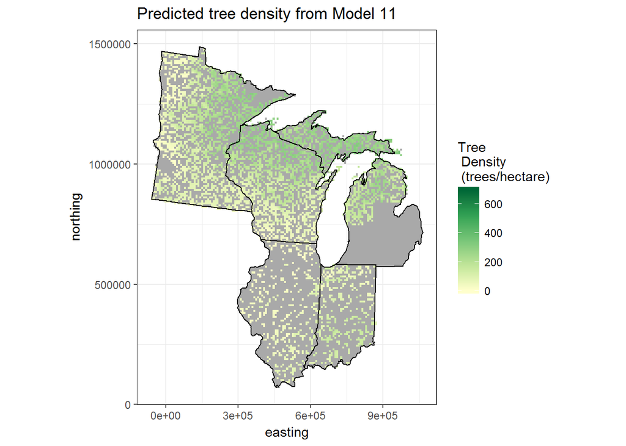

## Predicting Forest vs. Savanna (not density)

The above models are predicting density (continious variable) from continous envrionmental and climate covariates. However, we can also use the savanna/forest density classificaitons as our y variable and predict the probability a grid cell is forest (ecocode = 1, PLS density > 47 trees/ha) and savannna(ecocode = 0, PLSdensity < 47 trees/ha & >0.5 trees/ha) from continous environmental and climate covariates.

This method has the benefit of predicting the probability of forest (or the probability of savanna) given certain environmental conditions. For this analysis, we exclude prairie sites

|  | model | modeltype | formula | df | AIC |
| --- | --- | --- | --- | --- | --- |
| **logmod** | logmod | smooth | ecocode ~ s(MAP1910) | 8.718 | 3848 |
| **logmod2** | logmod2 | smooth | ecocode ~ s(MAP1910) | 26.33 | 3007 |
| **logmod3** | logmod3 | smooth | ecocode ~ s(MAP1910) | 34.19 | 2602 |
| **logmod4** | logmod4 | smooth | ecocode ~ s(MAP1910) | 41.52 | 2505 |
| **logmod5** | logmod5 | smooth | ecocode ~ s(MAP1910) | 46.8 | 2434 |
| **logmodL** | logmodL | linear | ecocode ~ s(MAP1910) | 2 | 4650 |
| **logmod2L** | logmod2L | linear | ecocode ~ s(MAP1910) | 4 | 3974 |
| **logmod3L** | logmod3L | linear | ecocode ~ s(MAP1910) | 5 | 3376 |
| **logmod4L** | logmod4L | linear | ecocode ~ s(MAP1910) | 6 | 3119 |
| **logmod5L** | logmod5L | linear | ecocode ~ s(MAP1910) | 7 | 2971 |

Looks like model number 5 has lowest AIC for the logistic/binomial model. Lets map out the probability of forest based on model with the lowest AIC value:

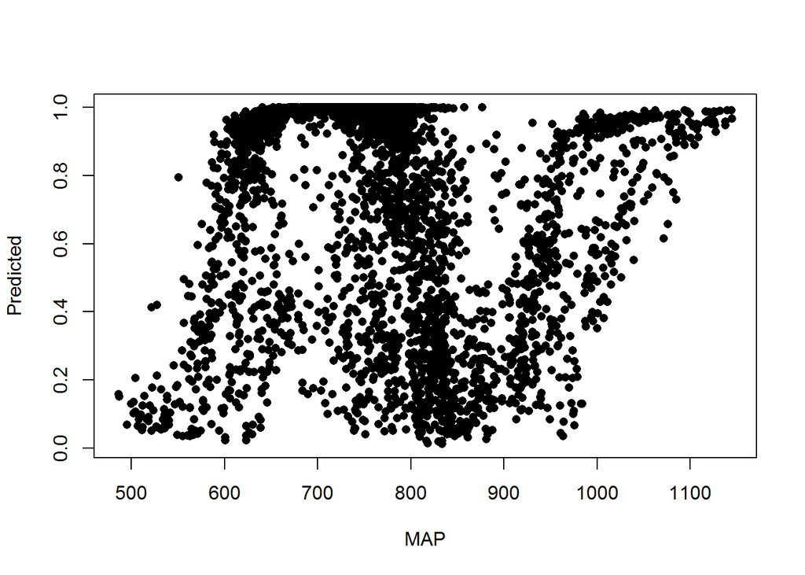

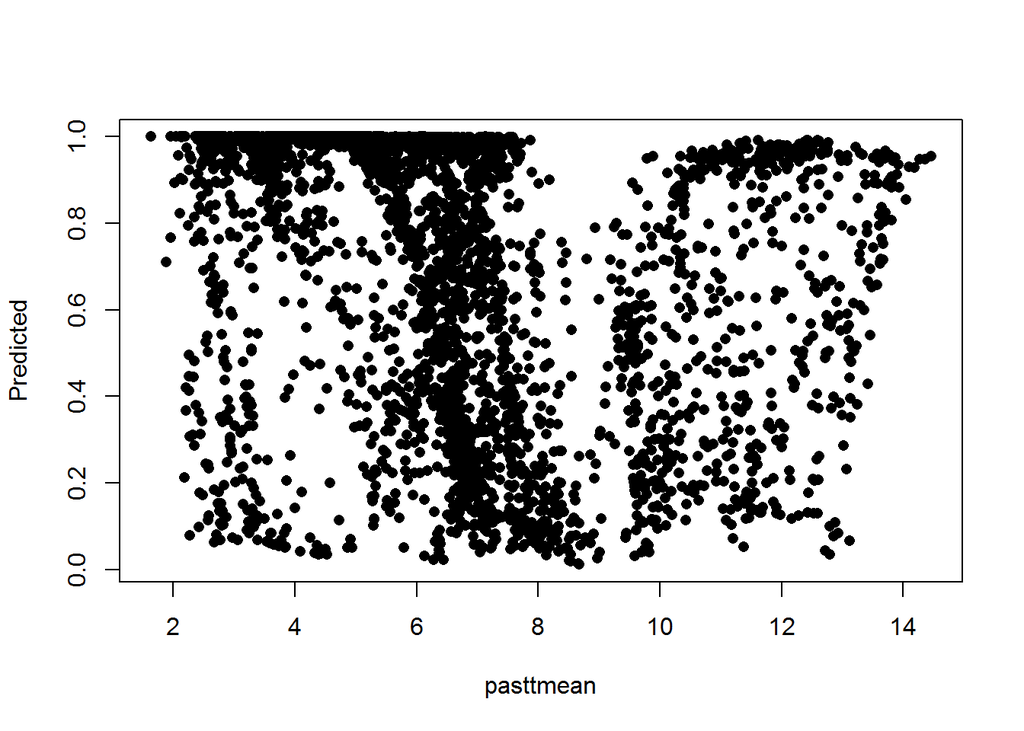

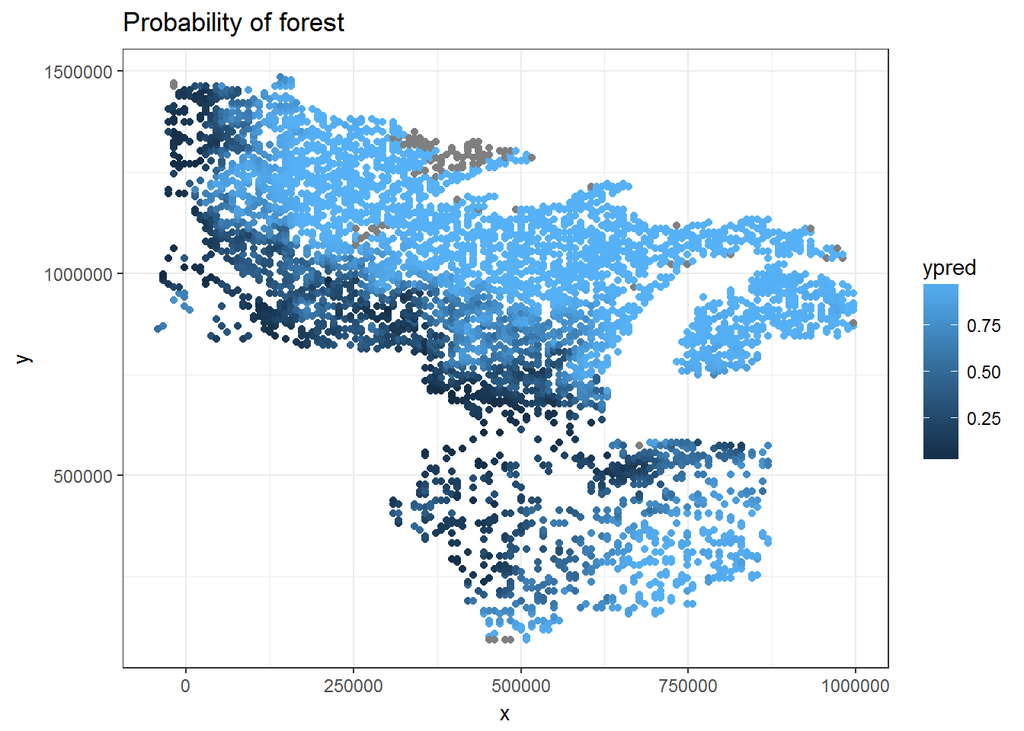

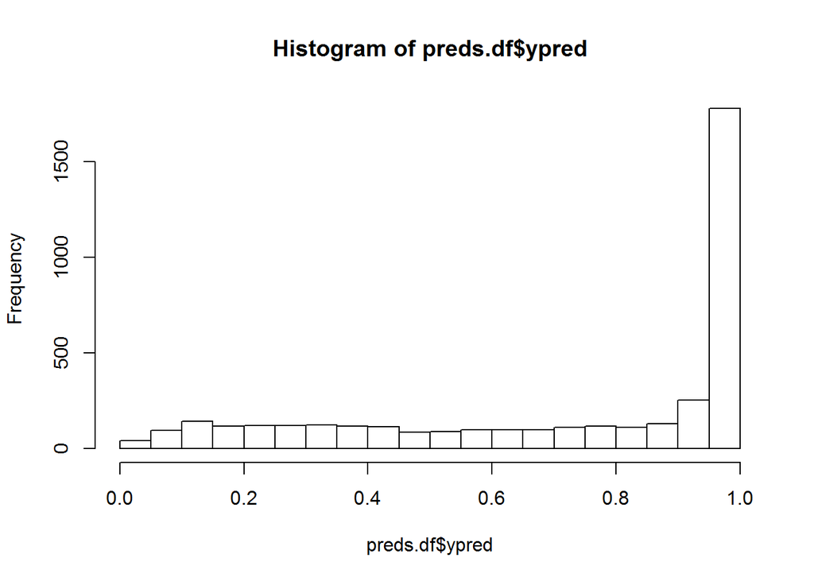

```
##    Min. 1st Qu.  Median    Mean 3rd Qu.    Max.    NA's
## 0.01131 0.44990 0.91050 0.72830 0.99760 1.00000      96
```

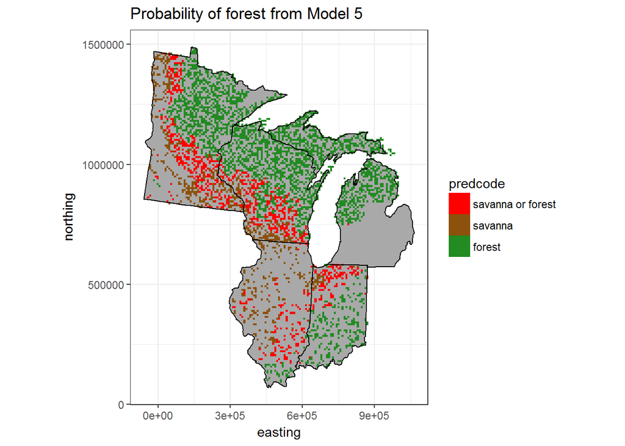

The above map shows ‘savana or forest’ places where the binomial familiy model predicted between 30-70% probability of forest. There are some places where the model predicts deterministic forest and deterministic savanna.